# Dimensionality reduction techniques

```r
date()
```

```
## [1] "Thu Nov 26 03:29:10 2020"
```

## Data

In this chapter the *human* dataset, which originates from the [United Nations Development Programme](http://hdr.undp.org/en/content/human-development-index-hdi), is analyzed. The code of data preparation along with the data is in my [Github repository](https://github.com/ritabei/IODS-project/blob/master/data/create_human.R).

Let’s load and explore the data.

```r
# Loading the data
human <- read.table('data/human.csv',sep = ',',header = T, row.names = 1)

# Looking at the structure of the dataset
str(human)
```

```
## 'data.frame':    155 obs. of  8 variables:
##  $ Edu2.FM  : num  1.007 0.997 0.983 0.989 0.969 ...
##  $ Labo.FM  : num  0.891 0.819 0.825 0.884 0.829 ...
##  $ Life.Exp : num  81.6 82.4 83 80.2 81.6 80.9 80.9 79.1 82 81.8 ...
##  $ Edu.Exp  : num  17.5 20.2 15.8 18.7 17.9 16.5 18.6 16.5 15.9 19.2 ...
##  $ GNI      : int  64992 42261 56431 44025 45435 43919 39568 52947 42155 32689 ...
##  $ Mat.Mor  : int  4 6 6 5 6 7 9 28 11 8 ...
##  $ Ado.Birth: num  7.8 12.1 1.9 5.1 6.2 3.8 8.2 31 14.5 25.3 ...
##  $ Parli.F  : num  39.6 30.5 28.5 38 36.9 36.9 19.9 19.4 28.2 31.4 ...
```

```r
dim (human)
```

```
## [1] 155   8
```

```r
names(human)
```

```
## [1] "Edu2.FM"   "Labo.FM"   "Life.Exp"  "Edu.Exp"   "GNI"       "Mat.Mor"
## [7] "Ado.Birth" "Parli.F"
```

The data set consists of 155 observations and 8 variables. Each observation has a name which indicates a country. The variables are:

*Edu2.FM*: ratio of proportion of females with at least secondary education and proportion of males with at least secondary education.

*Labo2.FM*: ratio of proportion of females in the labour force and proportion of males in the labour force.

*Life.Exp*: life expectancy at birth.

*Edu.Exp*: expected years of schooling.

*GNI*: gross National Income per capita.

*Mat.Mor*: maternal mortality ratio.

*Ado.Birth*: adolescent birth rate.

*Parli.F*: percetange of female representatives in parliament.

```r
# Looking at the summary of the variables
summary(human)
```

```
##     Edu2.FM          Labo.FM          Life.Exp        Edu.Exp
##  Min.   :0.1717   Min.   :0.1857   Min.   :49.00   Min.   : 5.40
##  1st Qu.:0.7264   1st Qu.:0.5984   1st Qu.:66.30   1st Qu.:11.25
##  Median :0.9375   Median :0.7535   Median :74.20   Median :13.50
##  Mean   :0.8529   Mean   :0.7074   Mean   :71.65   Mean   :13.18
##  3rd Qu.:0.9968   3rd Qu.:0.8535   3rd Qu.:77.25   3rd Qu.:15.20
##  Max.   :1.4967   Max.   :1.0380   Max.   :83.50   Max.   :20.20
##       GNI            Mat.Mor         Ado.Birth         Parli.F
##  Min.   :   581   Min.   :   1.0   Min.   :  0.60   Min.   : 0.00
##  1st Qu.:  4198   1st Qu.:  11.5   1st Qu.: 12.65   1st Qu.:12.40
##  Median : 12040   Median :  49.0   Median : 33.60   Median :19.30
##  Mean   : 17628   Mean   : 149.1   Mean   : 47.16   Mean   :20.91
##  3rd Qu.: 24512   3rd Qu.: 190.0   3rd Qu.: 71.95   3rd Qu.:27.95
##  Max.   :123124   Max.   :1100.0   Max.   :204.80   Max.   :57.50
```

All of the variables have different scales. The features, especially, *GNI*, *Mat.Mor*, *Ado.Birth* exhibit high variability.

Let’s look at the pairwise relationships between the variables.

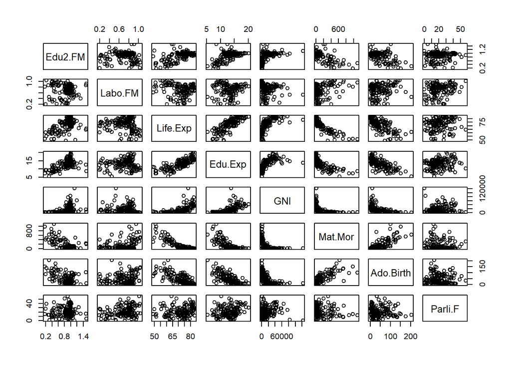

```r
# Plotting a matrix of the variables
pairs(human)
```

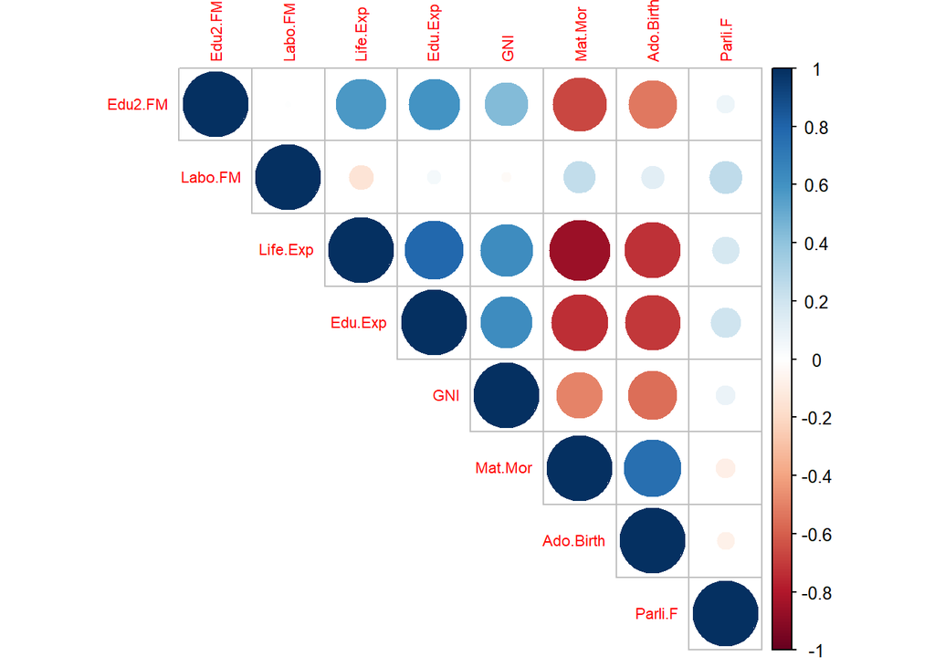

```r
library(corrplot)
library(dplyr)
# Computing the correlation matrix
cor(human) %>% corrplot(type = "upper", tl.cex=0.7)
```

Many variables seem to be correlated. For example, when *Life.Exp* (life expectancy at birth) increases, *Edu.Exp* (expected years of schooling) and *GNI* increase as well. With increasing *Life.Exp*, *Mat.Mor* (maternal mortality ratio) and *Ado.Birth* decreases (adolescent birth rate).

Let’s look at the distribution of the variables.

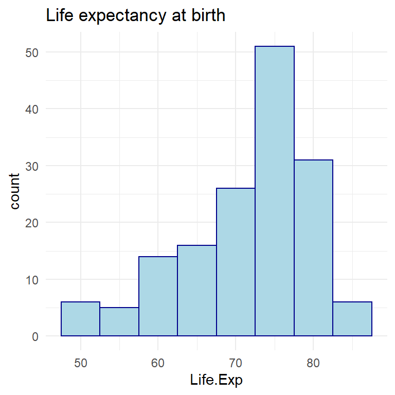

```r
library(ggplot2)
# Ploting a histogram of life expectancy at birth variable
ggplot(human, aes(x=Life.Exp)) +theme_minimal() + geom_histogram(color="darkblue", fill="lightblue", binwidth=5) + ggtitle("Life expectancy at birth")
```

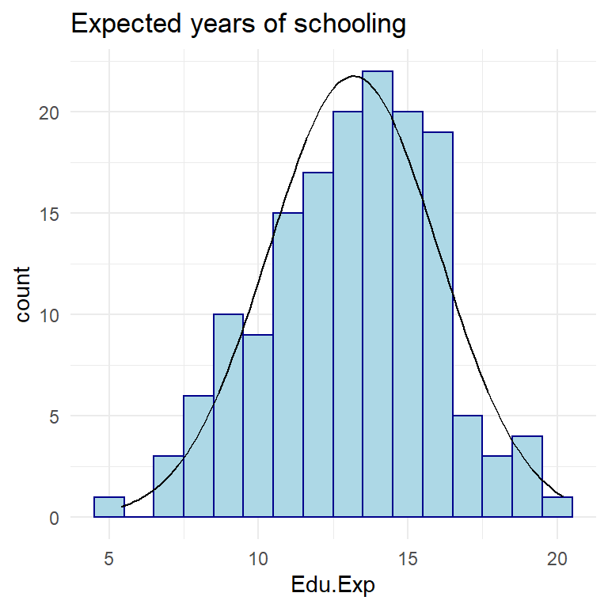

```r
library(ggplot2)
# Ploting a histogram of life expectancy at birth variable
ggplot(human, aes(x=Edu.Exp)) +theme_minimal() + geom_histogram(color="darkblue", fill="lightblue", binwidth=1) + ggtitle("Expected years of schooling")+ stat_function(fun = function(x) dnorm(x, mean = mean(human$Edu.Exp), sd = sd(human$Edu.Exp)) * 1 * nrow(human))
```

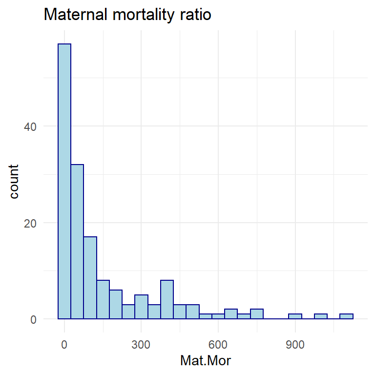

```r
library(ggplot2)
# Ploting a histogram of Mat.Mor variable
ggplot(human, aes(x=Mat.Mor)) +theme_minimal() + geom_histogram(color="darkblue", fill="lightblue", binwidth=50) + ggtitle("Maternal mortality ratio")
```

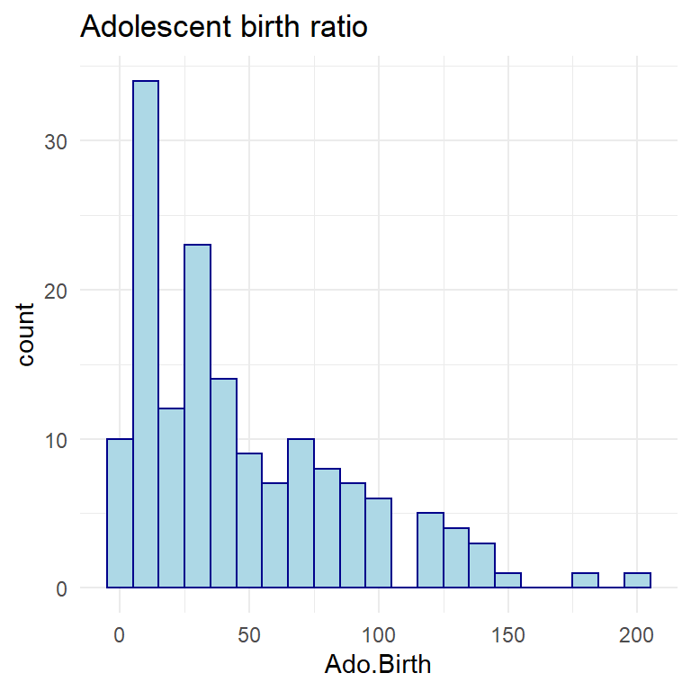

```r
library(ggplot2)
# Ploting a histogram of Ado.Birth variable
ggplot(human, aes(x=Ado.Birth)) +theme_minimal() + geom_histogram(color="darkblue", fill="lightblue", binwidth=10) + ggtitle("Adolescent birth ratio")
```

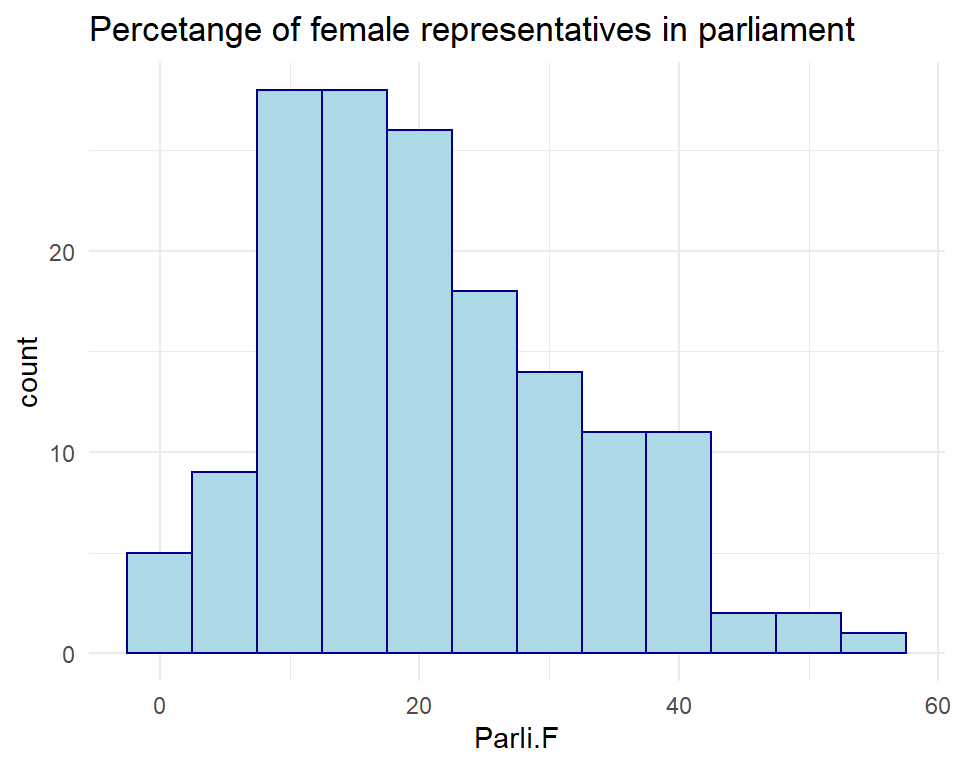

```r
library(ggplot2)
# Ploting a histogram of Parli.F variable
ggplot(human, aes(x=Parli.F)) +theme_minimal() + geom_histogram(color="darkblue", fill="lightblue", binwidth=5) + ggtitle("Percetange of female representatives in parliament")
```

Out of all distributions, only expected years of schooling resembles a normal distribution. Maternal mortality ratio is mostly quite low. However, there are very high ratio exceptions. Life expectancy has most counts between 70 and 80 years. In very few cases females take up more than 50% of parliament places.

## Principal Component Analysis (PCA)

In this section PCA is applied on non-standartized and standartized and results are compared at the end of the section.

### Non-standartized data

```r
options(warn = -1)
# Performing PCA (with the SVD method)
pca_human_ns <- prcomp(human)

# Creating and printing out a summary of pca_human
s <- summary(pca_human_ns)
s
```

```
## Importance of components:
##                              PC1      PC2   PC3   PC4   PC5   PC6    PC7    PC8
## Standard deviation     1.854e+04 185.5219 25.19 11.45 3.766 1.566 0.1912 0.1591
## Proportion of Variance 9.999e-01   0.0001  0.00  0.00 0.000 0.000 0.0000 0.0000
## Cumulative Proportion  9.999e-01   1.0000  1.00  1.00 1.000 1.000 1.0000 1.0000
```

```r
# Rounded percentages of variance captured by each PC
pca_pr <- round(100*s$importance[2,], digits = 1)

# Printing out the percentages of variance
pca_pr
```

```
## PC1 PC2 PC3 PC4 PC5 PC6 PC7 PC8
## 100   0   0   0   0   0   0   0
```

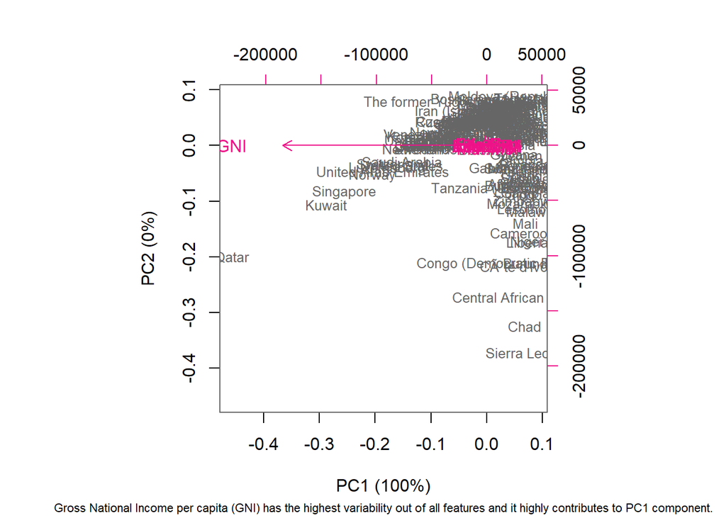

```r
# Creating an object pc_lab to be used as axis labels
pc_lab <- paste0(names(pca_pr), " (", pca_pr, "%)")

# Drawing a biplot
biplot(pca_human_ns, cex = c(0.8, 1), col = c("grey40", "deeppink2"), xlab = pc_lab[1], ylab = pc_lab[2], sub = 'Gross National Income per capita (GNI) has the highest variability out of all features and it highly contributes to PC1 component.', cex.sub = 0.7)
```

### Standartized data

```r
options(warn = -1)
# Standardizing the variables
human_std <- scale(human)


# Performing PCA (with the SVD method)
pca_human <- prcomp(human_std)


# Creating and printing out a summary of pca_human
s <- summary(pca_human)
s
```

```
## Importance of components:
##                           PC1    PC2     PC3     PC4     PC5     PC6     PC7
## Standard deviation     2.0708 1.1397 0.87505 0.77886 0.66196 0.53631 0.45900
## Proportion of Variance 0.5361 0.1624 0.09571 0.07583 0.05477 0.03595 0.02634
## Cumulative Proportion  0.5361 0.6984 0.79413 0.86996 0.92473 0.96069 0.98702
##                            PC8
## Standard deviation     0.32224
## Proportion of Variance 0.01298
## Cumulative Proportion  1.00000
```

```r
# Rounded percentages of variance captured by each PC
pca_pr <- round(100*s$importance[2,], digits = 1)

# Printing out the percentages of variance
pca_pr
```

```
##  PC1  PC2  PC3  PC4  PC5  PC6  PC7  PC8
## 53.6 16.2  9.6  7.6  5.5  3.6  2.6  1.3
```

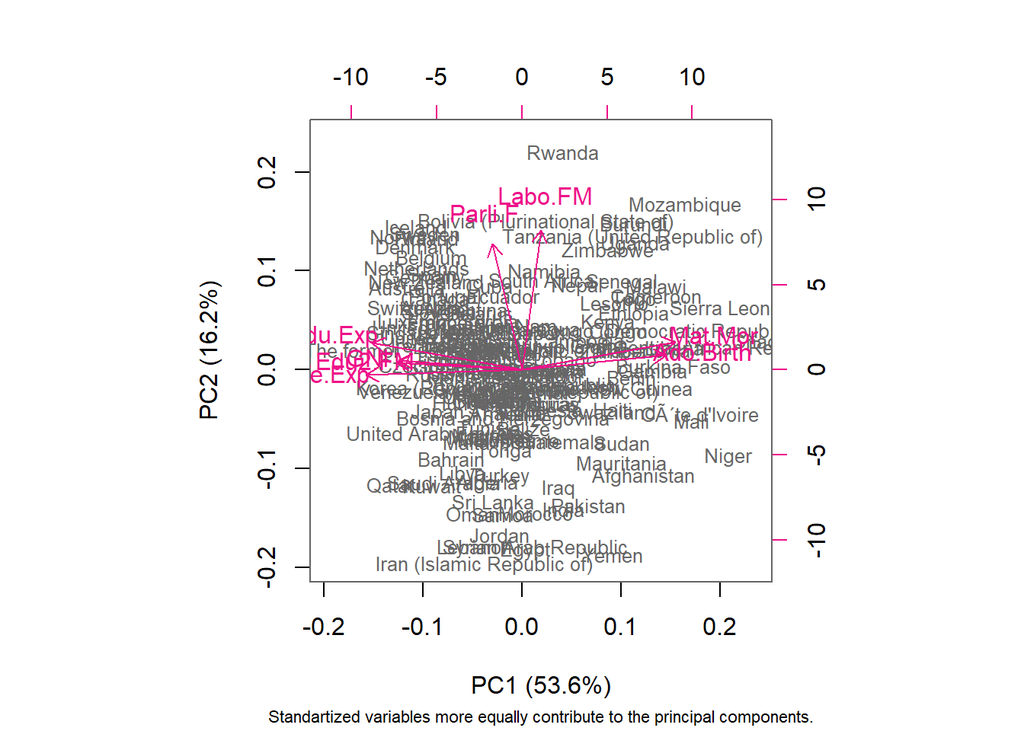

```r
# Creating an object pc_lab to be used as axis labels
pc_lab <- paste0(names(pca_pr), " (", pca_pr, "%)")

# Drawing a biplot
biplot(pca_human, cex = c(0.8, 1), col = c("grey40", "deeppink2"), xlab = pc_lab[1], ylab = pc_lab[2],sub= 'Standartized variables more equally contribute to the principal components.', cex.sub=0.7)
```

Standardization of the data set makes a very big difference. Without standardizing, very high variability in *GNI* highly contributes to the first principal component and thus, all variability in the data is explained only with PC1. When data is standardized, all variables contribute more equally to the components and the first principal component explains over 50% of variability in the data.

Ratio of proportion of females in the labour force and proportion of males in the labour force as well as percetange of female representatives in parliament are the only two variables which contribute to the second principal component. These two variables help to explain less variance in the data compared to education, life expectancy, maternal mortality and adolescent birth ratio variables.

## Multiple Correspondence Analysis

In this section the *tea* dataset from the package *FactoMineR* is used. It contains the answers of a questionnaire on tea consumption.

```r
# Loading tea dataset
library(FactoMineR)
data('tea')

# Looking at the structure of the dataset
str(tea)
```

```
## 'data.frame':    300 obs. of  36 variables:
##  $ breakfast       : Factor w/ 2 levels "breakfast","Not.breakfast": 1 1 2 2 1 2 1 2 1 1 ...
##  $ tea.time        : Factor w/ 2 levels "Not.tea time",..: 1 1 2 1 1 1 2 2 2 1 ...
##  $ evening         : Factor w/ 2 levels "evening","Not.evening": 2 2 1 2 1 2 2 1 2 1 ...
##  $ lunch           : Factor w/ 2 levels "lunch","Not.lunch": 2 2 2 2 2 2 2 2 2 2 ...
##  $ dinner          : Factor w/ 2 levels "dinner","Not.dinner": 2 2 1 1 2 1 2 2 2 2 ...
##  $ always          : Factor w/ 2 levels "always","Not.always": 2 2 2 2 1 2 2 2 2 2 ...
##  $ home            : Factor w/ 2 levels "home","Not.home": 1 1 1 1 1 1 1 1 1 1 ...
##  $ work            : Factor w/ 2 levels "Not.work","work": 1 1 2 1 1 1 1 1 1 1 ...
##  $ tearoom         : Factor w/ 2 levels "Not.tearoom",..: 1 1 1 1 1 1 1 1 1 2 ...
##  $ friends         : Factor w/ 2 levels "friends","Not.friends": 2 2 1 2 2 2 1 2 2 2 ...
##  $ resto           : Factor w/ 2 levels "Not.resto","resto": 1 1 2 1 1 1 1 1 1 1 ...
##  $ pub             : Factor w/ 2 levels "Not.pub","pub": 1 1 1 1 1 1 1 1 1 1 ...
##  $ Tea             : Factor w/ 3 levels "black","Earl Grey",..: 1 1 2 2 2 2 2 1 2 1 ...
##  $ How             : Factor w/ 4 levels "alone","lemon",..: 1 3 1 1 1 1 1 3 3 1 ...
```

[output cut: 22 more lines]

```r
dim(tea)
```

```
## [1] 300  36
```

```r
# Looking at the summaries of the variables
summary(tea)
```

```
##          breakfast           tea.time          evening          lunch
##  breakfast    :144   Not.tea time:131   evening    :103   lunch    : 44
##  Not.breakfast:156   tea time    :169   Not.evening:197   Not.lunch:256
##
##
##
##
##
##         dinner           always          home           work
##  dinner    : 21   always    :103   home    :291   Not.work:213
##  Not.dinner:279   Not.always:197   Not.home:  9   work    : 87
##
##
##
##
##
##         tearoom           friends          resto          pub
##  Not.tearoom:242   friends    :196   Not.resto:221   Not.pub:237
##  tearoom    : 58   Not.friends:104   resto    : 79   pub    : 63
##
##
##
##
##
##         Tea         How           sugar                     how
##  black    : 74   alone:195   No.sugar:155   tea bag           :170
##  Earl Grey:193   lemon: 33   sugar   :145   tea bag+unpackaged: 94
##  green    : 33   milk : 63                  unpackaged        : 36
##                  other:  9
##
##
##
##                   where                 price          age        sex
##  chain store         :192   p_branded      : 95   Min.   :15.00   F:178
##  chain store+tea shop: 78   p_cheap        :  7   1st Qu.:23.00   M:122
##  tea shop            : 30   p_private label: 21   Median :32.00
##                             p_unknown      : 12   Mean   :37.05
##                             p_upscale      : 53   3rd Qu.:48.00
##                             p_variable     :112   Max.   :90.00
##
```

[output cut: 25 more lines]

```
##  feminine    :129   Not.sophisticated: 85   No.slimming:255   exciting   :116
##  Not.feminine:171   sophisticated    :215   slimming   : 45   No.exciting:184
##
##
##
##
##
##         relaxing              effect.on.health
##  No.relaxing:113   effect on health   : 66
##  relaxing   :187   No.effect on health:234
##
##
##
##
##
```

This dataset has 300 observations and 36 variables. As there are many variables, I will selecte only some of them for further analysis.

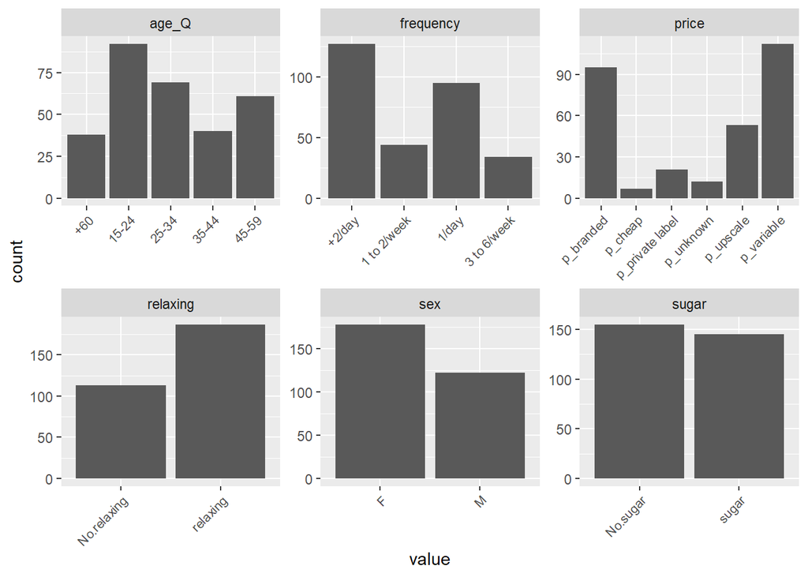

```r
library(dplyr)
library(ggplot2)
library(tidyr)
# Subsetting the dataset
selected_columns <- c ('age_Q', 'sex', 'price', 'sugar', 'frequency', 'relaxing' )
tea_selected <- dplyr::select(tea, one_of(selected_columns))

# Visualize the selected dataset
gather(tea_selected) %>% ggplot(aes(value)) + facet_wrap("key", scales = "free") + geom_bar() + theme(axis.text.x = element_text(angle = 45, hjust = 1, size = 8))
```

It seems that the highest tea consumption is in the age group of 15-24 year. The cheap tea isn’t chosen often. More people find tea drinking relaxing and more female than male drinks tea. Tea with no sugar is slightly more preferred.

Let’s do the multiple correspondence analysis.

```r
# Multiple correspondence analysis
mca <- MCA(tea_selected, graph = FALSE)

# Summarizing the model
summary(mca)
```

```
##
## Call:
## MCA(X = tea_selected, graph = FALSE)
##
##
## Eigenvalues
##                        Dim.1   Dim.2   Dim.3   Dim.4   Dim.5   Dim.6   Dim.7
## Variance               0.270   0.243   0.211   0.194   0.186   0.178   0.171
## % of var.             10.790   9.727   8.442   7.779   7.434   7.124   6.826
## Cumulative % of var.  10.790  20.517  28.958  36.737  44.171  51.295  58.121
##                        Dim.8   Dim.9  Dim.10  Dim.11  Dim.12  Dim.13  Dim.14
## Variance               0.165   0.149   0.144   0.142   0.122   0.117   0.113
## % of var.              6.596   5.971   5.767   5.674   4.873   4.660   4.510
## Cumulative % of var.  64.717  70.688  76.455  82.129  87.002  91.662  96.172
##                       Dim.15
## Variance               0.096
## % of var.              3.828
## Cumulative % of var. 100.000
##
## Individuals (the 10 first)
##                    Dim.1    ctr   cos2    Dim.2    ctr   cos2    Dim.3    ctr
## 1               |  0.529  0.346  0.046 |  1.139  1.778  0.211 |  0.637  0.640
## 2               | -0.786  0.764  0.336 |  0.476  0.311  0.123 |  0.604  0.576
## 3               | -0.733  0.664  0.351 | -0.281  0.108  0.052 |  0.041  0.003
## 4               |  0.701  0.607  0.320 | -0.026  0.001  0.000 |  0.131  0.027
## 5               | -0.429  0.227  0.111 |  0.093  0.012  0.005 | -0.166  0.043
## 6               |  0.557  0.383  0.090 | -0.093  0.012  0.003 |  0.478  0.360
## 7               | -0.104  0.013  0.003 |  0.331  0.150  0.035 | -0.344  0.187
## 8               | -0.020  0.000  0.000 | -0.266  0.097  0.026 | -0.273  0.118
## 9               | -0.251  0.078  0.024 |  0.125  0.021  0.006 | -0.907  1.300
## 10              | -0.251  0.078  0.024 |  0.125  0.021  0.006 | -0.907  1.300
##                   cos2
## 1                0.066 |
## 2                0.198 |
## 3                0.001 |
## 4                0.011 |
## 5                0.017 |
## 6                0.066 |
## 7                0.037 |
## 8                0.028 |
```

[output cut: 20 more lines]

```
## +60              -0.989 |  -1.258  15.824   0.229  -8.283 |
## F                -9.384 |   0.232   2.523   0.079   4.846 |
## M                 9.384 |  -0.339   3.680   0.079  -4.846 |
## p_branded        -3.333 |   0.556   7.726   0.143   6.543 |
## p_cheap          -2.355 |   0.358   0.236   0.003   0.957 |
## p_private label  -1.136 |   0.823   3.742   0.051   3.903 |
##
## Categorical variables (eta2)
##                   Dim.1 Dim.2 Dim.3
## age_Q           | 0.409 0.483 0.373 |
## sex             | 0.217 0.295 0.079 |
## price           | 0.112 0.133 0.544 |
## sugar           | 0.509 0.001 0.000 |
## frequency       | 0.234 0.273 0.190 |
## relaxing        | 0.137 0.274 0.080 |
```

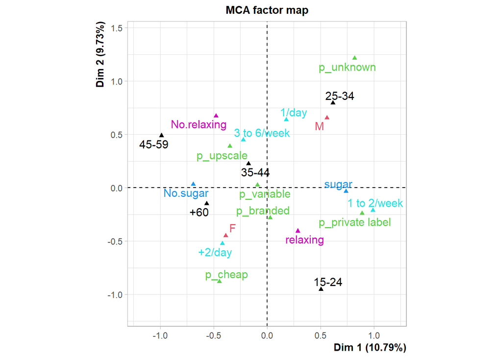

```r
# Visualizing the MCA
plot(mca, invisible=c("ind"), habillage = "quali")
```

The horizontal dimension explains 10.79% of the variance in the data whereas the vertical dimension explains only 9.73%. Together both dimension explain only around 20% of variance in the data set.

The graph in MCA presents the information in a condense form where the distance between variable categories gives a measure of their similarity.

Let’s look at some possible conclusions and see if they can be drawn from the data as well.

1. Tea with no sugar is more chosen by people from two older age groups.

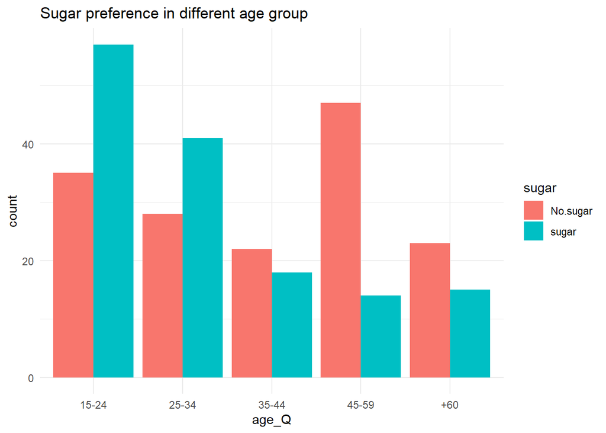

```r
# Initializing a plot of alc_use and going out
ggplot(tea_selected,
       aes(x = age_Q,
           fill = sugar )) +
  geom_bar(position = position_dodge(preserve = "single")) +labs(
   title = 'Sugar preference in different age group') + theme_minimal()
```

Yes, from the barplot we can see, that more peaople in youger age groups prefer tea with sugar and more people in older groups, prefer the tea without sugar.

2. Females drink tea more often than men (this can be seen in the initial barplots) and females are more likely to drink tea twice a day.

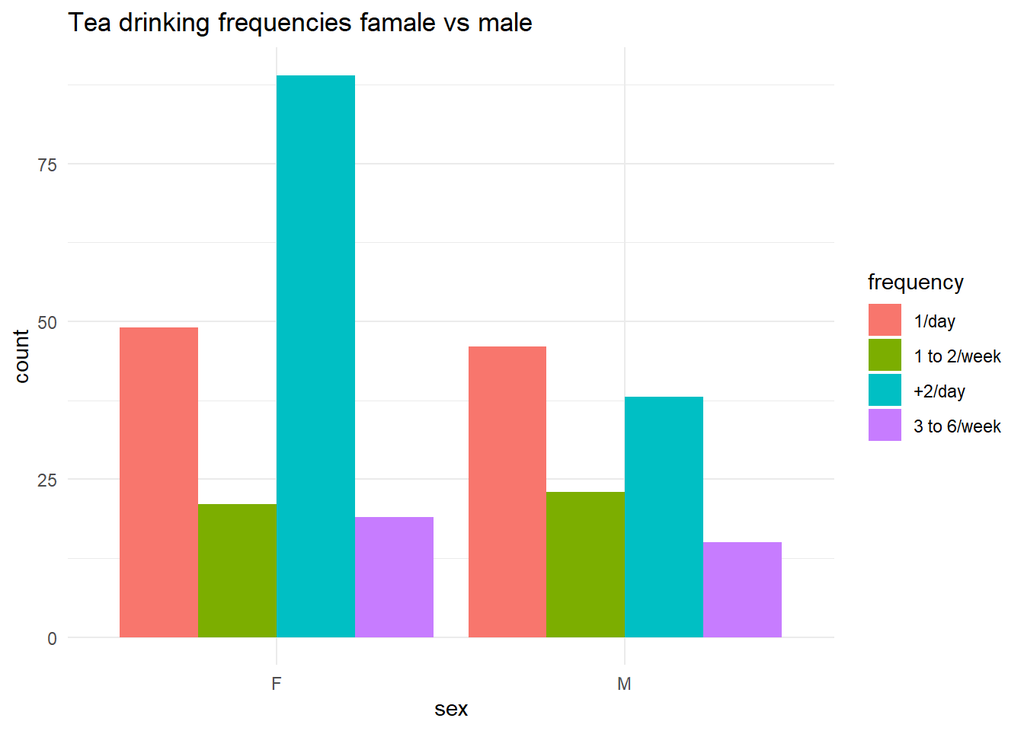

```r
# Initializing a plot of alc_use and going out
ggplot(tea_selected,
       aes(x = sex,
           fill = frequency )) +
  geom_bar(position = position_dodge(preserve = "single")) +labs(
   title = 'Tea drinking frequencies famale vs male') + theme_minimal()
```

Seems that this conclusion is visible in the data as well.

3. Sugar is chosen by people who drink tea least often (1 to 2 times per week).

[figure not shown]

```r
# Initializing a plot of alc_use and going out
ggplot(tea_selected,
       aes(x = frequency,
           fill = sugar )) +
  geom_bar(position = position_dodge(preserve = "single")) +labs(
   title = 'Sugar preference in different age group') + theme_minimal()
```

It seems that this conclusion can be drawn from the data as well.